# Projekt ZED

## Ustawienia

```r
knitr::opts_chunk$set(echo = TRUE)
set.seed(23)
```

## Biblioteki

```r
library(dplyr)
library(ggplot2)
library(caret)
library(lattice)
library(reshape)
source("https://raw.githubusercontent.com/briatte/ggcorr/master/ggcorr.R")
```

## Wczytanie danych

```r
#wczytanie danych ze strony do data.frame
data_set <- read.csv("http://www.cs.put.poznan.pl/dbrzezinski/teaching/zed/elektrownie.csv")
#dodanie do data.frame kolumny zawierającej godzinę i miesiąc, wyodrębione z kolumny "data"
data_set$godzina <- as.numeric(format(as.POSIXct(factor(data_set$data),format="%m/%d/%Y %H:%M"),"%H"))
data_set$miesiac <- as.numeric(format(as.POSIXct(factor(data_set$data),format="%m/%d/%Y %H:%M"),"%m"))
```

## Kod przetwarzający dane

```r
#not_empty_radiation <- dataset1 %>% filter(irradiamento != 0)
#empty_radiation <- dataset1 %>% filter(irradiamento == 0)

#start <- Sys.time()
#for(i in 1:nrow(empty_radiation))
#{
    #row <- empty_radiation[i,]
    #m <- not_empty_radiation %>% filter(miesiac == empty_radiation[i,"miesiac"], godzina == empty_radiation[i,"godzina"])
    #if (nrow(m) ==0)
    #{
      #empty_radiation[i,"irradiamento"] <- 0
    #}
    #else
    #{
      #empty_radiation[i,"irradiamento"] <- mean(m[["irradiamento"]])
    #}
#}
#end <- Sys.time()
#print(end - start)
#data_set <- rbind(empty_radiation, not_empty_radiation)
```

## Wstępna analiza danych

Zaimportowany zbiór zawiera dane pochodzące z czujników umieszczonych przy panelach fotowoltaicznych, umieszczonych w trzech sąsiadujących elektrowni słonecznych we Włoszech. Zbiór składa się z 235790 wierdzy oraz 51 kolumn. Celem analizy jest znalezienie czynnika, który najtrafniej pozwoli przewidzieć wartość wytworzonej energi przez panele fotowoltaiczne. Każdy wiersz zawiera uśrednione dane z jednej godziny pomiarów pojedynczej jednostki fotowoltaicznej.

Kolumny zbioru danych dotyczą specyfikacji panelu (identyfikator panelu, modelu, firmy), wartości czynników pogodowych (napromieniowanie, ciła wiatru, zachmurzenie, ciśnienie, wilgotność, punkt rosy), położenia geograficznego(długość i szerokość geograficzna panelu, wysokość, azymut), daty pomiaru (dzien, rok, pelna data) oraz wartości współczynnika “pcnm”.

W zbiorze danych znajują się wartości zerowe, nie tylko w miejscach gdzie żeczywiście odnotowany został taki pomiar, ale także gdzie, poprzez usterke panelu nie doszło do pomiaru. Powyższy wniosek opiera się na analizie pomiarów dokonanych o zbliżonej porze dnia, roku oraz stopniu zachmurzenia.

Położenie geograficzne nie jest bardzo istotne, ponieważ wszystkie panele są rozmieszczone w stosunkowo niewielkich odległościach (sasiednie elektrownie na terenie jednego kraju, takie samej strefy klimatycznej i wysokości nad poziomem morza). W kategorii czynników pogodowych, najbardziej istotne jest napromieniowanie oraz zachmurzenie, ponieważ to od stopnia nasłoneczenie zależy wartość kwh. Z tym bezpośrednio związana jest data pomiaru, ponieważ siła napromieniowania jest różna w zależności od pory dnia i roku. Dlatego też wartości “puste” najbardziej dotlikwe są dla danych dotyczących napromieniowania.

Nastepnie sporządzone zostały hostogramy dla atrybutów oraz korelacja pomiędzy poszczególnymi zmiennymi zbioru danych. Zgodnie z początkową analizą korelacja ukazała, ze na ilość wytwarzanej energii ma wpływ promieniowanie, a także wilgotność oraz azymut. Te argumenty zostały wskazane do regresji.

## Sekcję podsumowującą rozmiar zbioru i podstawowe statystyki

```r
#uwtorzenie podsumowania, statystyk ze zbioru danych "dataset".
selected_data <- select(data_set,idsito, idbrand, idmodel,temperatura_ambiente, irradiamento, pressure, windspeed, humidity, cloudcover,dewpoint, kwh, azimuth)
summary(selected_data)
```

```
##      idsito          idbrand          idmodel       temperatura_ambiente
##  Min.   :0.0000   Min.   :0.0000   Min.   :0.0000   Min.   :0.0450
##  1st Qu.:0.1000   1st Qu.:0.0830   1st Qu.:0.1670   1st Qu.:0.2120
##  Median :0.2250   Median :0.1670   Median :0.2080   Median :0.3480
##  Mean   :0.2147   Mean   :0.1519   Mean   :0.2426   Mean   :0.3734
##  3rd Qu.:0.3250   3rd Qu.:0.1670   3rd Qu.:0.2920   3rd Qu.:0.5300
##  Max.   :0.4250   Max.   :0.4170   Max.   :0.7500   Max.   :0.8180
##   irradiamento       pressure        windspeed          humidity
##  Min.   :0.0000   Min.   :0.0000   Min.   :0.00000   Min.   :0.1600
##  1st Qu.:0.0000   1st Qu.:0.7480   1st Qu.:0.04200   1st Qu.:0.5400
##  Median :0.0350   Median :0.7530   Median :0.06600   Median :0.7000
##  Mean   :0.1091   Mean   :0.6504   Mean   :0.07622   Mean   :0.6844
##  3rd Qu.:0.2040   3rd Qu.:0.7550   3rd Qu.:0.10200   3rd Qu.:0.8400
##  Max.   :0.7100   Max.   :0.7690   Max.   :0.69600   Max.   :1.0000
##    cloudcover       dewpoint           kwh            azimuth
##  Min.   :0.000   Min.   :0.1390   Min.   :0.0000   Min.   :0.1280
##  1st Qu.:0.230   1st Qu.:0.5350   1st Qu.:0.0000   1st Qu.:0.2950
##  Median :0.310   Median :0.6190   Median :0.0490   Median :0.4250
##  Mean   :0.359   Mean   :0.6055   Mean   :0.1688   Mean   :0.4546
##  3rd Qu.:0.510   3rd Qu.:0.6830   3rd Qu.:0.3320   3rd Qu.:0.6350
##  Max.   :1.000   Max.   :0.8650   Max.   :1.0000   Max.   :0.8180
```

## Szczegółowa analizę wartości atrybutów

```r
#Wybranie określonych kolumn ze zbioru dataset, po wcześniejszej pobieżnej analizie ich ważności. Wybrane zostały głównie kolumny związane z czynnikami pogodowymi a także identyfikator panela fotowoltaicznego oraz wartość prezentującą wytworzoną energię.
selected_data <- select(data_set,idsito, idbrand, idmodel,temperatura_ambiente, irradiamento, pressure, windspeed, humidity, cloudcover,dewpoint, kwh, azimuth)

#W poniższym kroku konstruowany jest wykres za pomocą funkcji "ggplot", który przedtawia rozkład wartości każdego z aktrybutów.
p <- ggplot(data = melt(selected_data), mapping = aes(x = value)) +
  geom_histogram(bins=10, aes(fill=..count..)) +
  labs(title = "Rozkład wartości atrybutów") +
  facet_wrap(~variable, ncol=4, scales = 'free_x') +
  scale_x_continuous(labels = scales::comma) +
  scale_fill_gradient("Count", low="blue", high="pink") +
  theme_bw()
```

```
## Using  as id variables
```

```r
ggplotly(p)
```

[interactive chart not shown]

## Korelacja pomiędzy wybranymi atrybutami

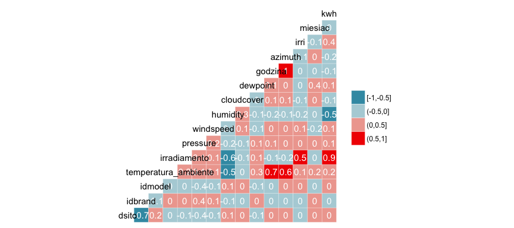

```r
#Ponowne wybranie określonych kolumn ze zbioru.
selected_data <- select(data_set,idsito, idbrand, idmodel,temperatura_ambiente, irradiamento, pressure, windspeed, humidity, cloudcover,dewpoint,godzina,azimuth, irri, miesiac, kwh)

#Utworzenie wykresu korealcji, za pomocą funkcji "ggcorr"
ggcorr(selected_data, nbreaks = 4, label = TRUE, label_size = 4, label_color = "white")
```

## Prezentacja zmiany wytwarzanej energii w czasie i przestrzeni

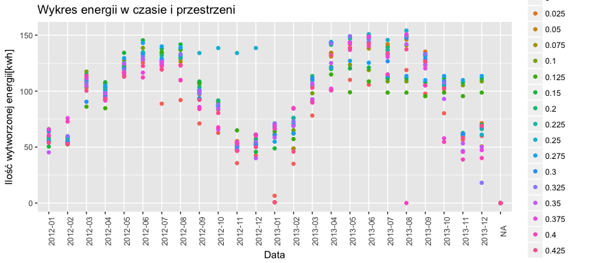

```r
data_set <- data_set %>% mutate(data_format=format(as.POSIXct(data, format='%m/%d/%Y %H:%M'), "%Y-%m"))
kwh_plot <- data_set %>% group_by(data_format, idsito) %>% summarise(suma=sum(kwh))
ggplot(data = kwh_plot, mapping = aes(x=data_format, y=suma, color=factor(idsito), group=factor(idsito))) +
  geom_point() +
  labs(title = "Wykres energii w czasie i przestrzeni", x = "Data", y = "Ilość wytworzonej energii[kwh]") +
  theme(axis.text.x = element_text(angle = 90))
```

## Regresor przewidujący wytwarzaną energię

```r
set.seed(23)
df_clear <- data_set %>% select(idsito, irradiamento, humidity, azimuth, kwh)

inTraining <- createDataPartition(
    y = df_clear$idsito,
    p = 0.85,
    list = FALSE
)

training <- df_clear[inTraining,]
testing <- df_clear[-inTraining,]

ctrl <- trainControl(method="repeatedcv", number=2, repeats=5)

model <- train(
    kwh ~ idsito + humidity + irradiamento + azimuth,
    data = training,
    method = "lm",
    metric = "RMSE",
    trControl = ctrl
)

predict_kwh <- predict(model, testing)
dat <- data.frame(pred =  predict_kwh, obs = testing$kwh)
defaultSummary(dat)
```

```
##       RMSE   Rsquared        MAE
## 0.10601667 0.74591640 0.06441813
```

## Analizę ważności atrybutów

Na podstawie analizy atrybutów oraz modelu regresji można stwierdzić, że do przewidzenia wartość wytworzonej energiiprzez pojedynczy panel w danej godzinie najlepiej posłuży parametr dotyczący napromieniowania, wilgotnosci oraz azymutu. Trafność regresji została oszacowana na podstawie miary RMSE i jej wartość jest na poziomie 0.10.

```r
#Podsumowanie modelu
print(summary(model))
```

```
##
## Call:
## lm(formula = .outcome ~ ., data = dat)
##
## Residuals:
##      Min       1Q   Median       3Q      Max
## -0.66355 -0.03877 -0.01276  0.02126  1.02328
##
## Coefficients:
##               Estimate Std. Error t value Pr(>|t|)
## (Intercept)   0.110289   0.001611   68.44   <2e-16 ***
## idsito        0.097016   0.001771   54.78   <2e-16 ***
## humidity     -0.115525   0.001628  -70.96   <2e-16 ***
## irradiamento  1.257519   0.002220  566.47   <2e-16 ***
## azimuth      -0.045076   0.001277  -35.31   <2e-16 ***
## ---
## Signif. codes:  0 '***' 0.001 '**' 0.01 '*' 0.05 '.' 0.1 ' ' 1
##
## Residual standard error: 0.1053 on 200417 degrees of freedom
## Multiple R-squared:  0.7503, Adjusted R-squared:  0.7503
## F-statistic: 1.506e+05 on 4 and 200417 DF,  p-value: < 2.2e-16
```